# Alpha Omega preliminary results

## Supplementation period

### Omega-3 supplementation

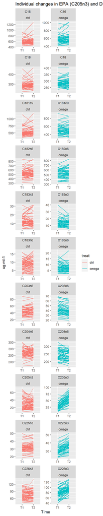

| fa | T1_ctrl | T1_omega | T2_ctrl | T2_omega | estimate | se | t | p | lwr | upr |
| --- | --- | --- | --- | --- | --- | --- | --- | --- | --- | --- |
| C16 | 591.1 (95.1) | 576.6 (104.4) | 605.1 (124.7) | 593.2 (124) | 0.929 | 16.024 | 0.058 | 0.954 | −30.801 | 32.658 |
| C18 | 289.2 (35.7) | 284.6 (30.5) | 295.3 (37.8) | 288.9 (34.3) | −2.860 | 4.747 | −0.602 | 0.548 | −12.259 | 6.540 |
| C181c9 | 532.7 (137.4) | 519 (115.3) | 549.8 (150) | 506.3 (119.7) | −33.268 | 16.212 | −2.052 | 0.042 | −65.369 | −1.167 |
| C182n6 | 520.5 (94.5) | 529.9 (95.3) | 534.7 (95.3) | 532.4 (98.8) | −7.629 | 10.474 | −0.728 | 0.468 | −28.367 | 13.110 |
| C183n3 | 13 (5.1) | 14.1 (6.3) | 13.1 (6.6) | 13.5 (5.2) | −0.247 | 0.798 | −0.309 | 0.758 | −1.826 | 1.333 |
| C183n6 | 8.6 (3.1) | 7.9 (3.6) | 8.7 (3.6) | 7.1 (3.3) | −1.366 | 0.490 | −2.790 | 0.006 | −2.336 | −0.396 |
| C203n6 | 44.5 (11.9) | 42.6 (11.3) | 45.4 (13.1) | 38.8 (9.9) | −5.794 | 1.191 | −4.864 | 0.000 | −8.153 | −3.436 |
| C204n6 | 267.3 (32.8) | 249.6 (33.6) | 271.4 (29.7) | 241.6 (33.9) | −16.988 | 4.136 | −4.108 | 0.000 | −25.177 | −8.799 |
| C205n3 | 29.6 (14.9) | 27.1 (12.9) | 29.2 (12.2) | 57.7 (17.8) | 29.664 | 2.431 | 12.202 | 0.000 | 24.850 | 34.478 |
| C225n3 | 31.8 (5.4) | 30.6 (4.9) | 32 (5.9) | 35.6 (5.9) | 4.547 | 0.622 | 7.304 | 0.000 | 3.314 | 5.780 |
| C226n3 | 76.8 (19.7) | 77.2 (18.8) | 77.1 (18.9) | 94.8 (16.7) | 17.959 | 2.248 | 7.989 | 0.000 | 13.508 | 22.410 |

### Glucose metabolism

Table 1: ANCOVA results Omega-3 vs. CTRL (T2 ~ T1 + treat)

| analyste | min | estimate | se | t | p | lwr | upr |
| --- | --- | --- | --- | --- | --- | --- | --- |
| glucose | baseline | −0.050 | 0.091 | −0.551 | 0.583 | −0.231 | 0.131 |
| glucose | min60 | −0.197 | 0.282 | −0.699 | 0.487 | −0.758 | 0.364 |
| cpeptide | baseline | −67.751 | 49.641 | −1.365 | 0.176 | −166.386 | 30.884 |
| cpeptide | min60 | 2.969 | 148.502 | 0.020 | 0.984 | −292.242 | 298.180 |
| HOMA2B | baseline | 0.223 | 6.849 | 0.033 | 0.974 | −13.387 | 13.832 |
| HOMA2B | min60 | 6.864 | 10.715 | 0.641 | 0.523 | −14.440 | 28.168 |
| HOMA2S | baseline | 2.825 | 2.743 | 1.030 | 0.306 | −2.626 | 8.276 |
| HOMA2S | min60 | 0.529 | 0.829 | 0.638 | 0.525 | −1.119 | 2.177 |
| HOMA2IR | baseline | −0.152 | 0.112 | −1.350 | 0.180 | −0.375 | 0.072 |
| HOMA2IR | min60 | −0.058 | 0.434 | −0.134 | 0.894 | −0.920 | 0.804 |

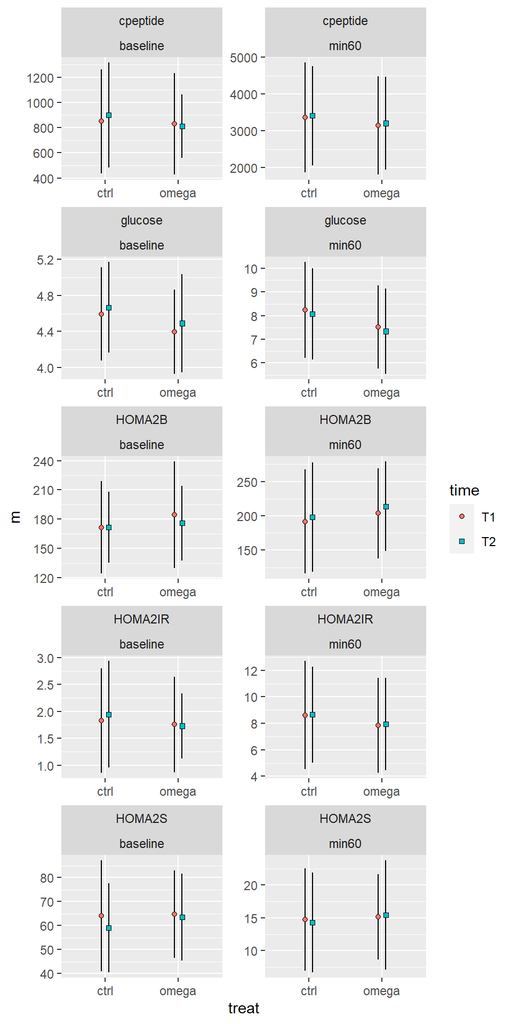

Table 2: Maximal glucose during glucose tolerance test

| treat | Mean | SD | Min | Max | n_above10 | n_above11 | n |
| --- | --- | --- | --- | --- | --- | --- | --- |
| T1 |  |  |  |  |  |  |  |
| ctrl | 9.14 | 1.96 | 5.56 | 14.92 | 23 | 10 | 66 |
| omega | 8.68 | 1.98 | 5.00 | 18.27 | 11 | 6 | 61 |
| T2 |  |  |  |  |  |  |  |
| ctrl | 9.20 | 2.08 | 5.64 | 16.98 | 20 | 11 | 65 |
| omega | 8.48 | 1.57 | 5.85 | 11.98 | 9 | 7 | 60 |

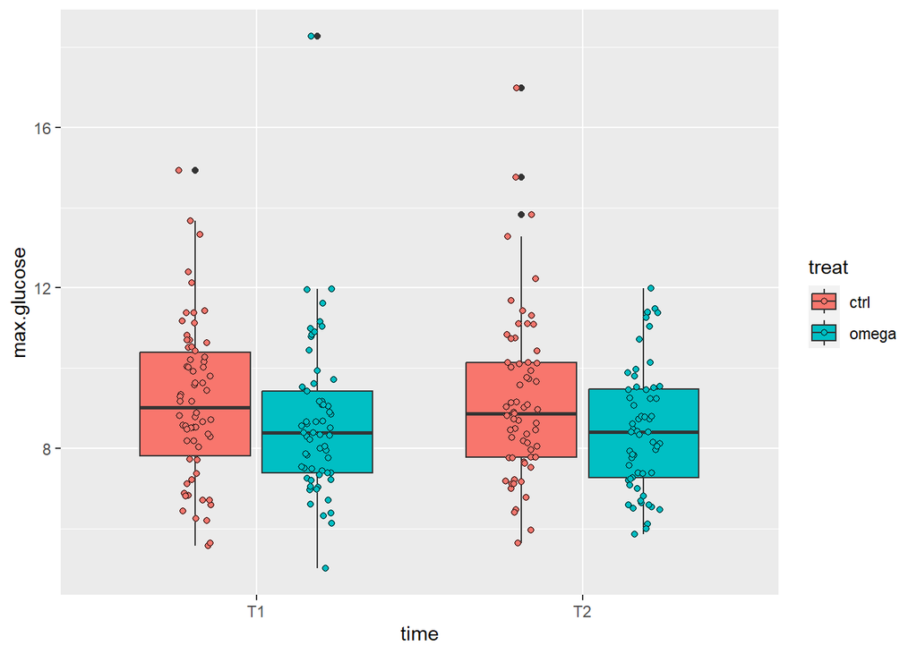

Peak glucose from glucose tolerance test

Table 3: Resting and 2-h glucose from glucose tolerance test

| min | Mean | SD | Min | Max | n_above7 | n_above11 | n |
| --- | --- | --- | --- | --- | --- | --- | --- |
| T1 - ctrl |  |  |  |  |  |  |  |
| 0 | 4.43 | 0.60 | 2.62 | 6.79 | 0 | 0 | 66 |
| 120 | 6.42 | 1.88 | 3.14 | 13.33 | 17 | 2 | 65 |
| T1 - omega |  |  |  |  |  |  |  |
| 0 | 4.36 | 0.49 | 2.86 | 6.03 | 0 | 0 | 61 |
| 120 | 6.21 | 2.10 | 3.10 | 18.27 | 9 | 1 | 60 |
| T2 - ctrl |  |  |  |  |  |  |  |
| 0 | 4.66 | 0.71 | 2.68 | 8.15 | 1 | 0 | 65 |
| 120 | 5.99 | 1.79 | 3.01 | 11.93 | 13 | 2 | 64 |
| T2 - omega |  |  |  |  |  |  |  |
| 0 | 4.48 | 0.50 | 3.27 | 6.47 | 0 | 0 | 60 |
| 120 | 5.71 | 1.12 | 3.55 | 8.65 | 7 | 0 | 60 |

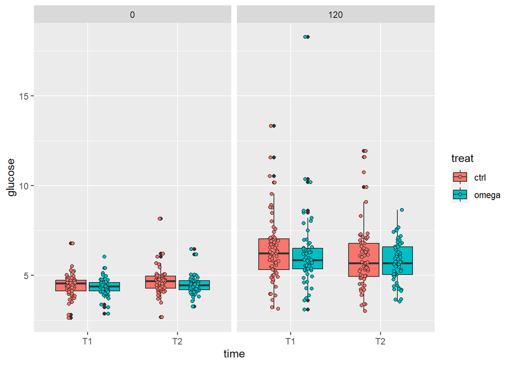

Resting glucose from glucose tolerance test

### Blood variables

See Figure 1 for descriptive effects across time-points.

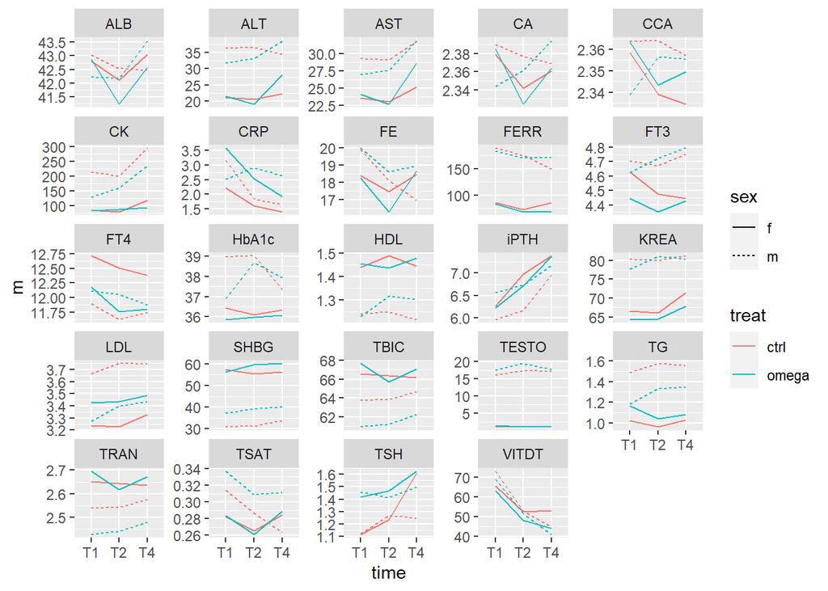

Figure 1: Tendencies over time per blood analyte separated by treatment and sex.

Modelling effects of treatment over the supplementation period.

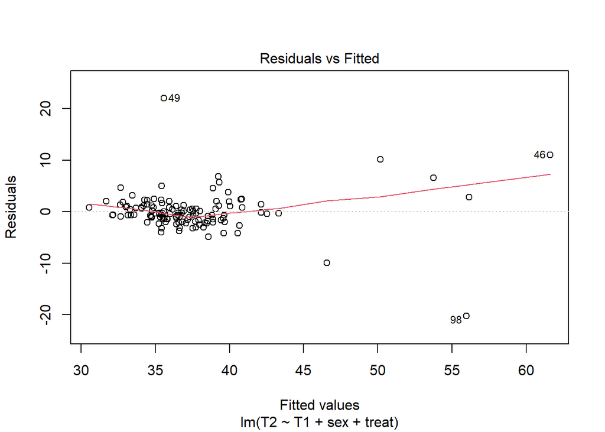

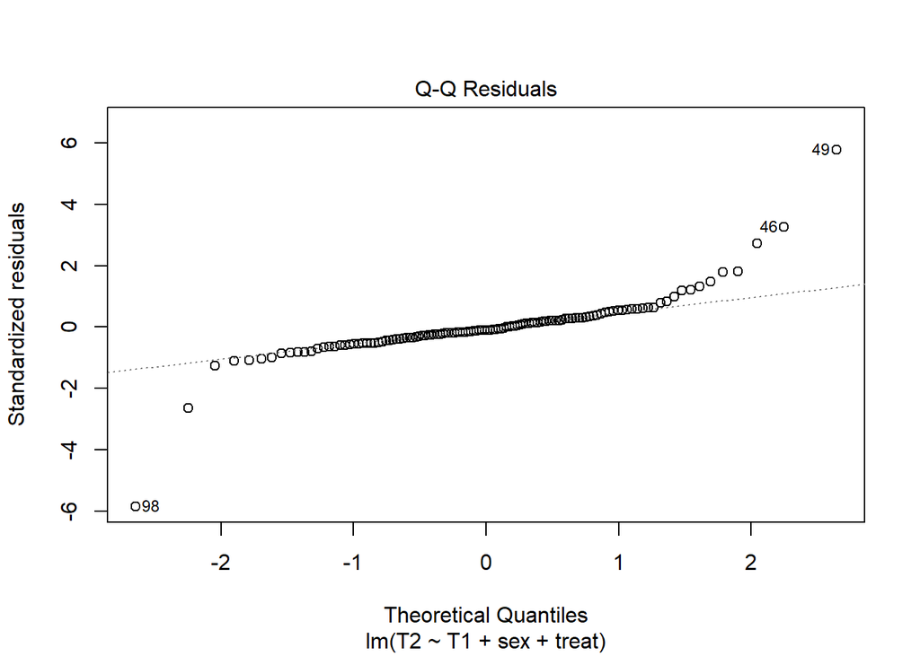

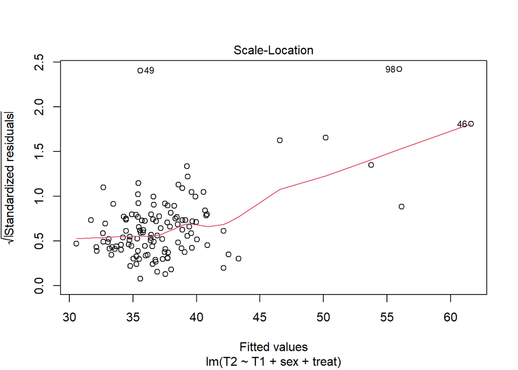

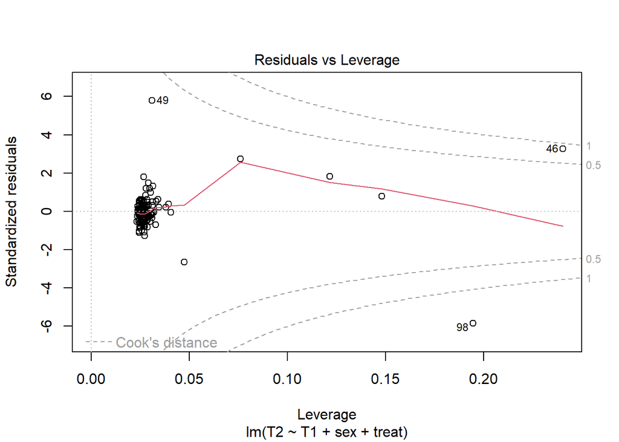

Table 4: Effects of TREATMENT on blood variables at T2. Controlling for sex and T1 values.

| analyste | estimate | se | t | p | lwr | upr |
| --- | --- | --- | --- | --- | --- | --- |
| ALT | 0.714 | 1.364 | 0.524 | 0.602 | −1.988 | 3.417 |
| ALB | −0.348 | 0.375 | −0.928 | 0.356 | −1.091 | 0.395 |
| AST | 0.247 | 0.893 | 0.277 | 0.782 | −1.522 | 2.017 |
| CA | −0.005 | 0.012 | −0.413 | 0.680 | −0.028 | 0.018 |
| CCA | 0.004 | 0.009 | 0.489 | 0.626 | −0.013 | 0.022 |
| CK | 15.101 | 21.022 | 0.718 | 0.474 | −26.536 | 56.739 |
| CRP | 0.975 | 0.561 | 1.737 | 0.085 | −0.137 | 2.086 |
| FE | −0.370 | 0.919 | −0.402 | 0.688 | −2.190 | 1.450 |
| FERR | 3.903 | 4.301 | 0.907 | 0.366 | −4.618 | 12.423 |
| FT3 | 0.039 | 0.071 | 0.551 | 0.583 | −0.101 | 0.180 |
| FT4 | −0.088 | 0.141 | −0.626 | 0.533 | −0.367 | 0.191 |
| HDL | −0.007 | 0.026 | −0.281 | 0.779 | −0.058 | 0.044 |
| KREA | 0.790 | 0.900 | 0.879 | 0.381 | −0.992 | 2.573 |
| LDL | −0.010 | 0.080 | −0.119 | 0.905 | −0.169 | 0.150 |
| TG | 0.012 | 0.090 | 0.135 | 0.893 | −0.166 | 0.190 |
| TBIC | −0.988 | 0.779 | −1.267 | 0.208 | −2.531 | 0.556 |
| TRAN | −0.039 | 0.031 | −1.267 | 0.208 | −0.101 | 0.022 |
| TSH | −0.032 | 0.097 | −0.331 | 0.742 | −0.224 | 0.160 |
| VITDT | −0.504 | 1.624 | −0.311 | 0.757 | −3.721 | 2.713 |
| iPTH | 0.159 | 0.259 | 0.613 | 0.541 | −0.355 | 0.673 |
| SHBG | 3.894 | 2.487 | 1.566 | 0.120 | −1.035 | 8.823 |
| TESTO | 0.280 | 0.477 | 0.587 | 0.559 | −0.666 | 1.226 |
| TSAT | 0.002 | 0.015 | 0.160 | 0.873 | −0.028 | 0.032 |
| HbA1c | 0.768 | 0.705 | 1.090 | 0.278 | −0.628 | 2.165 |

Very preliminary modelling of interaction between T1 and treatment. Is this a valid model?

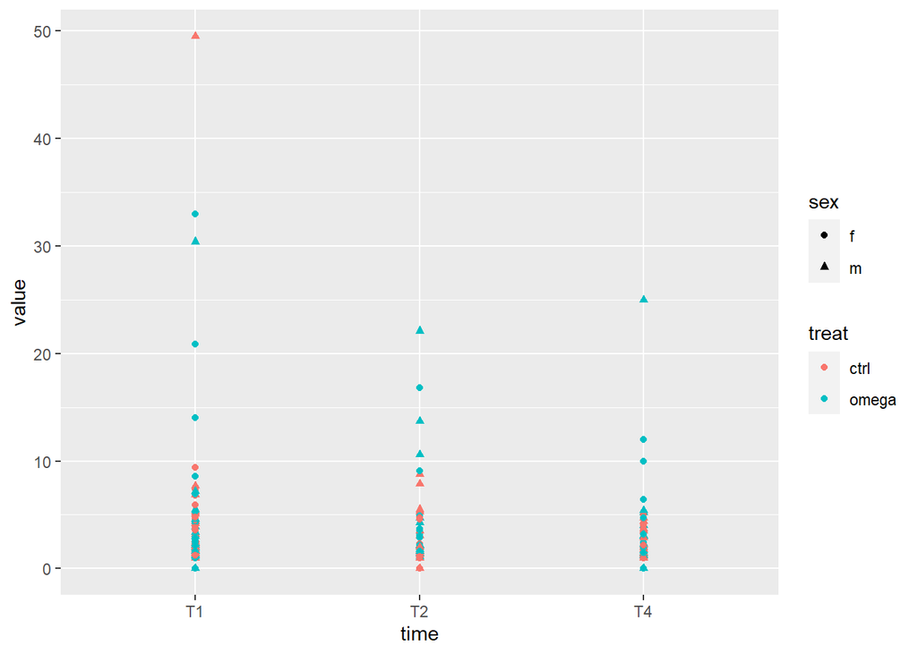

```
Call:
lm(formula = T2 ~ T1 + treat:T1 + sex, data = d)

Residuals:
    Min      1Q  Median      3Q     Max
-2.3743 -0.2876 -0.0720  0.1588  3.8275

Coefficients:
              Estimate Std. Error t value Pr(>|t|)
(Intercept)   -0.08236    0.08369  -0.984 0.327084
T1             1.02482    0.08215  12.475  < 2e-16 ***
sexm           0.22606    0.12001   1.884 0.062083 .
T1:treatomega -0.47362    0.12937  -3.661 0.000377 ***
---
Signif. codes:  0 '***' 0.001 '**' 0.01 '*' 0.05 '.' 0.1 ' ' 1

Residual standard error: 0.6528 on 118 degrees of freedom
  (5 observations deleted due to missingness)
Multiple R-squared:  0.6336,    Adjusted R-squared:  0.6243
F-statistic: 68.03 on 3 and 118 DF,  p-value: < 2.2e-16
```

```
Call:
lm(formula = T2 ~ T1 + treat + sex, data = d)

Residuals:
    Min      1Q  Median      3Q     Max
-3.6018 -0.2650 -0.0626  0.1956  3.9057

Coefficients:
            Estimate Std. Error t value Pr(>|t|)
(Intercept) -0.13680    0.10709  -1.277   0.2040
T1           0.84233    0.06712  12.549   <2e-16 ***
treatomega   0.13642    0.12521   1.090   0.2782
sexm         0.26089    0.12578   2.074   0.0402 *
---
Signif. codes:  0 '***' 0.001 '**' 0.01 '*' 0.05 '.' 0.1 ' ' 1

Residual standard error: 0.6854 on 118 degrees of freedom
  (5 observations deleted due to missingness)
Multiple R-squared:  0.5961,    Adjusted R-squared:  0.5858
F-statistic: 58.05 on 3 and 118 DF,  p-value: < 2.2e-16
```

### ECSS abstract: Relative fat mass is not negatively associated with muscle adaptations to resistance training

RM-condition was not associated with changes in lean mass/thickness (when controlling for relative fat mass). Relative fat mass was not associated with lean mass/thickness. The 30RM condition is associated with lower increase in maximal strength. A relationship that is partly reversed with increased fat mass (not significant).

Descriptive statistics Vastus lateralis thickness (VL) at time 2 and 4 (T) and relative fat mass at T2

| var | m | s | n |
| --- | --- | --- | --- |
| f |  |  |  |
| VLT2 | 23.609 | 6.116 | 49 |
| VLT4 | 26.672 | 6.363 | 49 |
| rel.fmT2 | 41.768 | 6.712 | 49 |
| m |  |  |  |
| VLT2 | 26.983 | 6.365 | 46 |
| VLT4 | 30.721 | 6.284 | 46 |
| rel.fmT2 | 27.666 | 4.818 | 46 |

Model results T4 vastus lateralis thickness explained by baseline thickness (VLthick_T2), sex and relative fat mass (%) at time 2 (rel.fm_T2). For every % change in relative fat mass, vastus lateralis changes ~ 0.03 mm.

|  | Estimate | Std..Error | df | t.value | Pr...t.. |
| --- | --- | --- | --- | --- | --- |
| (Intercept) | 6.118 | 1.737 | 90.397 | 3.521 | 6.748 × 10<sup>−4</sup> |
| VLthick_T2 | 0.918 | 0.032 | 110.406 | 28.627 | 6.598 × 10<sup>−53</sup> |
| rel.fm_T2 | −0.028 | 0.036 | 85.277 | −0.781 | 0.437 |
| sexm | 0.455 | 0.66 | 85.643 | 0.688 | 0.493 |

Model results T4 vastus lateralis thickness explained by baseline thickness (VLthick_T2), sex, condition and relative fat mass (%) at time 2 (rel.fm_T2). For every % change in relative fat mass, vastus lateralis changes ~ 0.03 mm.

|  | Estimate | Std..Error | df | t.value | Pr...t.. |
| --- | --- | --- | --- | --- | --- |
| (Intercept) | 5.965 | 1.742 | 91.258 | 3.425 | 9.237 × 10<sup>−4</sup> |
| VLthick_T2 | 0.917 | 0.032 | 110.447 | 28.575 | 7.665 × 10<sup>−53</sup> |
| rel.fm_T2 | −0.028 | 0.036 | 85.054 | −0.782 | 0.436 |
| conditionRM30 | 0.389 | 0.267 | 87.833 | 1.456 | 0.149 |
| sexm | 0.459 | 0.661 | 85.423 | 0.695 | 0.489 |

Model results T4 vastus lateralis thickness explained by baseline thickness (VLthick_T2), sex, condition and relative fat mass (%) at time 2 (rel.fm_T2), and their interaction. For every % change in relative fat mass, vastus lateralis changes ~ 0.03 mm.

|  | Estimate | Std..Error | df | t.value | Pr...t.. |
| --- | --- | --- | --- | --- | --- |
| (Intercept) | 5.671 | 1.815 | 106.979 | 3.124 | 0.002 |
| VLthick_T2 | 0.917 | 0.032 | 110.259 | 28.57 | 8.760 × 10<sup>−53</sup> |
| rel.fm_T2 | −0.02 | 0.039 | 114.065 | −0.512 | 0.61 |
| conditionRM30 | 0.966 | 1.062 | 86.798 | 0.909 | 0.366 |
| sexm | 0.458 | 0.661 | 85.448 | 0.694 | 0.49 |
| rel.fm_T2:conditionRM30 | −0.017 | 0.029 | 86.785 | −0.561 | 0.576 |

Model results T4 lean mass explained by baseline lean mass (lean_T2), sex and relative fat mass (%) at time 2 (rel.fm_T2). For every % change in relative fat mass, lean mass changes ~ 3 g.

|  | Estimate | Std..Error | t.value | Pr...t.. |
| --- | --- | --- | --- | --- |
| (Intercept) | 2,180.042 | 637.2 | 3.421 | 9.432 × 10<sup>−4</sup> |
| lean_T2 | 0.873 | 0.032 | 27.046 | 1.051 × 10<sup>−44</sup> |
| rel.fm_T2 | 3.001 | 13.441 | 0.223 | 0.824 |
| sexm | 907.449 | 288.703 | 3.143 | 0.002 |

Model results T4 legpress 1RM explained by baseline leg press (T2), sex and relative fat mass (%) at time 2 (rel.fm). For every % change in relative fat mass, lean mass changes ~ 0.2 kg.

|  | Estimate | Std..Error | df | t.value | Pr...t.. |
| --- | --- | --- | --- | --- | --- |
| (Intercept) | 23.099 | 10.855 | 93.206 | 2.128 | 0.036 |
| T2 | 0.921 | 0.04 | 161.014 | 22.952 | 1.222 × 10<sup>−52</sup> |
| rel.fm | 0.156 | 0.245 | 83.637 | 0.636 | 0.527 |
| sexm | 4.576 | 4.025 | 96.048 | 1.137 | 0.258 |

Model results T4 legpress 1RM explained by baseline leg press (T2), sex and relative fat mass (%) at time 2 (rel.fm) and condition.

|  | Estimate | Std..Error | df | t.value | Pr...t.. |
| --- | --- | --- | --- | --- | --- |
| (Intercept) | 25.464 | 10.875 | 93.501 | 2.342 | 0.021 |
| T2 | 0.913 | 0.04 | 162.793 | 23.022 | 4.544 × 10<sup>−53</sup> |
| rel.fm | 0.153 | 0.245 | 83.09 | 0.624 | 0.535 |
| conditionRM30 | −2.582 | 0.969 | 83.094 | −2.665 | 0.009 |
| sexm | 4.92 | 4.021 | 95.873 | 1.224 | 0.224 |

Model results T4 legpress 1RM explained by baseline leg press (T2), sex and relative fat mass (%) at time 2 (rel.fm) and condition, and their interaction.

|  | Estimate | Std..Error | df | t.value | Pr...t.. |
| --- | --- | --- | --- | --- | --- |
| (Intercept) | 28.859 | 11.052 | 100.417 | 2.611 | 0.01 |
| T2 | 0.915 | 0.04 | 162.834 | 23.137 | 2.402 × 10<sup>−53</sup> |
| rel.fm | 0.051 | 0.253 | 93.573 | 0.201 | 0.841 |
| conditionRM30 | −10.779 | 4.941 | 83.409 | −2.182 | 0.032 |
| sexm | 4.879 | 4.023 | 96.115 | 1.213 | 0.228 |
| rel.fm:conditionRM30 | 0.229 | 0.135 | 83.76 | 1.691 | 0.095 |

Mean and SD (m, s) relative (%) and absolute (kg) change per condition in legpress strength from T2 to T4.

| condition | change | m | s |
| --- | --- | --- | --- |
| RM10 | abs_change | 21.11420 | 15.46061 |
| RM30 | abs_change | 18.42529 | 13.35289 |
| RM10 | rel_change | 15.92527 | 11.96022 |
| RM30 | rel_change | 14.13929 | 10.78094 |

Mean and SD (m, s) relative (%) and absolute (g) change lean mass (total) from T2 to T4

| change | m | s |
| --- | --- | --- |
| abs_change | 405.255 | 806.581 |
| rel_change | 2.427 | 4.354 |

Mean and SD (m, s) relative (%) and absolute (mm) change in vastus lateralis thickness per condition from T2 to T4.

| condition | change | m | s |
| --- | --- | --- | --- |
| RM10 | abs_change | 3.101 | 2.345 |
| RM30 | abs_change | 3.474 | 2.476 |
| RM10 | rel_change | 13.187 | 9.999 |
| RM30 | rel_change | 14.993 | 11.339 |

## Precision nutrition and metabolism (Abstract)

Introduction: Omega-3 fatty acids (n-3 FAs) have received considerable attention for their potential health benefits, including improvements in muscle mass and function during disuse and disease and in the elderly. Obesity is associated with several conditions potentially alleviated by n-3FAs, such as inactivity/disuse, anabolic resistance and inflammation. Resistance exercise (RE) is a well-established intervention for promoting muscle hypertrophy, muscle function, and metabolic health. This study aimed to investigate the individual and combined effects of n-3 FAs and RE on muscle hypertrophy, function and glucose metabolism in healthy middle-aged, inactive individuals across a wide BMI-range.

Methods: 95 (♂: 46, ♀: 49, age: 47.8 (SD:7.2) years, fat-% range: 21.1-56.2) healthy, untrained participants completed 7 weeks of daily supplementation with a placebo or 500mg EPA and 270mg DHA, and 13 weeks of bi-weekly supervised heavy progressive resistance exercise with continued supplementation. Exercises were leg press, knee extension, knee flexion, bench press and dumbell row. Upper body exercises were performed to failure with three sets of 10 repetitions to failure (RM). For legs, the training was unilateral, with each leg randomly assigned to three sets of 10RM or three sets of 30RM to failure. Dual-energy X-ray absorptiometry and ultrasound of the thigh were completed at baseline and after the intervention to measure total lean body mass and vastus lateralis thickness, respectively. Blood glucose (0, 15,30, 45, 60, 90 and 120 min) and c-peptide (0 and 60 min) were measured after ingestion of 75 grams of glucose. After a familiarisation session, leg press 1RM was performed before and after the intervention.

Conclusion: Supplementation with n-3 FAs did not alter the effects of heavy progressive resistance training on muscle growth, muscle strength or glucose metabolism in healthy, inactive middle-aged individuals.